# Processamento e Visualização de Dados

Prof. Cesar Henrique Comin

# Visão geral do curso

## Assuntos abordados

- A parte bruta: Pré-processamento e limpeza de dados.
- A parte bonita: Design e gramática da visualização para a comunicação.

## Assuntos abordados

### I. Pré-processamento de Dados

- **Limpeza de Dados:**
  - Identificação e tratamento de valores ausentes.
  - Detecção e tratamento de ruídos e *outliers*.
- **Transformação de Dados:**
  - Normalização, padronização e escalonamento.
  - Discretização e binarização de variáveis contínuas.
  - Codificação de variáveis categóricas.
- **Redução de Dados e Dimensionalidade:**
  - Seleção de características: filtros e wrappers.
  - Extração de características: intuição sobre PCA e transformações lineares.
  - Seleção e amostragem de instâncias.
- **Tratamento de Dados Desbalanceados:**
  - Técnicas de reamostragem (Oversampling e Undersampling).

## Assuntos abordados

### II. Mapeamento e Estética de Visualização

- **A Gramática dos Gráficos:**
  - Mapeamento de dados em atributos estéticos (posição, forma, tamanho, cor).
  - Sistemas de coordenadas e eixos.
  - Tipos de escalas (lineares, logarítmicas, temporais).
- **Visualização por Tipo de Dado:**
  - **Quantidades e Proporções:** Gráficos de barras, agrupamentos, gráficos de pizza e mosaicos.
  - **Distribuições:** Histogramas, gráficos de densidade, boxplots e violin plots.
  - **Relações (X-Y):** Gráficos de dispersão, correlações e linhas de tendência.
  - **Séries Temporais e Dados Espaciais:** Representação de tendências ao longo do tempo e introdução a mapas.
- **Visualização de Incerteza:**
  - Barras de erro, bandas de confiança e distribuições de probabilidade.

## Assuntos abordados

### III. Design, Comunicação e Boas Práticas

- **O Uso Estratégico das Cores:**
  - Escalas qualitativas, sequenciais e divergentes.
  - Considerações de acessibilidade e contraste.
- **Composição de Figuras:**
  - Títulos, legendas, anotações e proporções.
  - Técnicas para lidar com sobreposição de dados.
  - Redundância visual: quando usar múltiplos atributos estéticos para a mesma variável.
- **Storytelling e Armadilhas Comuns:**
  - O que faz um gráfico ser considerado “ruim” (enganoso, ilegível ou desnecessariamente complexo).
  - Como construir narrativas visuais.

## A Explosão de Dados e a Computação

- Vivemos na era do Big Data.
- O volume de dados gerados cresce exponencialmente a cada ano.
- O grande desafio: Ter dados não é a mesma coisa que ter informações úteis.
- O papel do Cientista da Computação: automatizar, otimizar, estruturar e extrair valor dos dados.

## A Ilusão do Dado Pronto

- Datasets acadêmicos clássicos (Kaggle, UCI) enganam: eles costumam ser limpos e tabulados.
- A Realidade da Indústria: Dados são ruidosos, incompletos e desestruturados.
- Cerca de 80% do tempo em um projeto de dados real é gasto apenas na preparação e limpeza.

## Procedimentos de avaliação

- Serão realizadas 5 atividades em sala de aula e 2 projetos práticos
- A nota final am atividades, $NA$, será calculada como a média simples das 5 atividades, descartando a menor nota.
- A nota final em projetos será calculada como

$$\begin{equation}
NP = 0.3*P1 + 0.7*P2
\end{equation}$$

- A nota final do curso, $MF$, será calculada como

$$\begin{equation}
NF = 0.4*NA + 0.6*NP
\end{equation}$$

### Contato

- Email: chcomin@gmail.com
- Fórum do curso no AVA

### Github da disciplina

- https://github.com/chcomin/curso-processamento-e-visualizacao-de-dados
- Todos os slides e códigos serão postados no github

## Bibliografia

- O curso é baseado em dois livros-texto principais:
  - Wilke, Claus O. Fundamentals of data visualization. O’Reilly Media, 2019.
  - García, Salvador, Julián Luengo, and Francisco Herrera. Data preprocessing in data mining. Vol. 72. Springer International Publishing, 2015.

# Descoberta de Conhecimento em Bases de Dados (KDD)

## O Pipeline KDD (Knowledge Discovery in Databases)

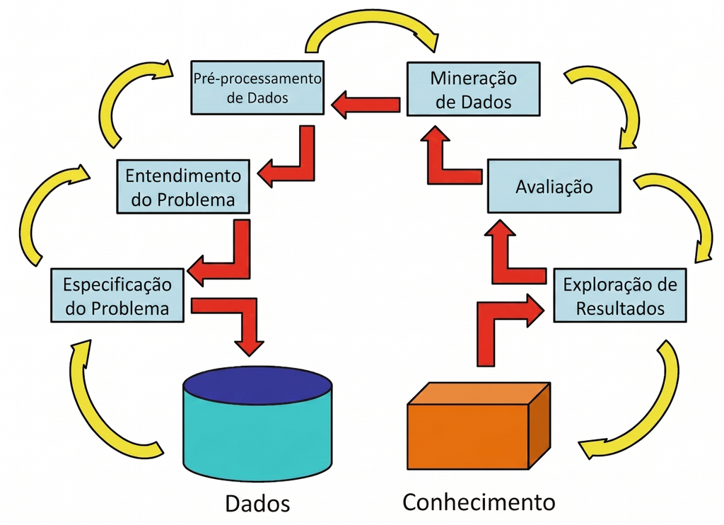

- Foco central na disciplina: Pré-processamento, Avaliação e Exploração.

Imagem adaptada de García et al. Data preprocessing in data mining.

## 1. Especificação do Problema

- **Designação do Domínio:** Delimitar a área de aplicação do problema.
- **Conhecimento Prévio:** Integrar o conhecimento já obtido por especialistas da área.
- **Objetivos:** Definir quais são os objetivos finais perseguidos pelo usuário final.

## 2. Compreensão do Problema

- **Compreensão dos Dados:** Entendimento profundo dos dados selecionados para a abordagem.
- **Contexto do Especialista:** Associar os dados ao conhecimento do negócio.
- **Objetivo Final:** Alcançar um alto grau de confiabilidade. A equipe técnica precisa entender a semântica do que os dados representam no mundo real.

## 3. Pré-processamento de Dados

- **Limpeza:** Remoção de ruídos e dados inconsistentes.
- **Integração:** Combinação de múltiplas fontes de dados em uma única base.
- **Transformação:** Consolidação dos dados em formatos apropriados para tarefas específicas ou operações de agregação.
- **Redução:** Seleção e extração de características e instâncias.

## 4. Mineração de Dados

- O processo essencial de extrair padrões de dados válidos.
- **Escolha da Tarefa:** Definir se o problema é de classificação, regressão, clusterização ou associação.
- **Escolha do Algoritmo:** Selecionar o método matemático/computacional adequado.
- **Ajuste e Validação:** Acomodar o algoritmo ao problema através do ajuste de parâmetros essenciais e procedimentos robustos de validação.

## 5. Avaliação

- **Estimativa:** Quantificar o desempenho do modelo ou padrão encontrado.
- **Interpretação:** Analisar os padrões minerados com base em medidas de interesse.
- O padrão encontrado é trivial, esperado, ou realmente uma descoberta nova e útil?

## 6. Exploração dos Resultados

- O que fazer com o conhecimento extraído?
- **Uso Direto:** Tomada de decisão baseada diretamente no padrão encontrado.
- **Integração:** Incorporar o modelo/conhecimento em outro sistema para processos automatizados.
- **Visualização:** Reportar e comunicar o conhecimento descoberto de forma clara e honesta através de ferramentas visuais.

# Visualização de Dados

## Por que Visualizar?

**O Quarteto de Anscombe**

Estatísticas descritivas (média, variância, correlação) idênticas, mas que escondem padrões completamente diferentes aos olhos:

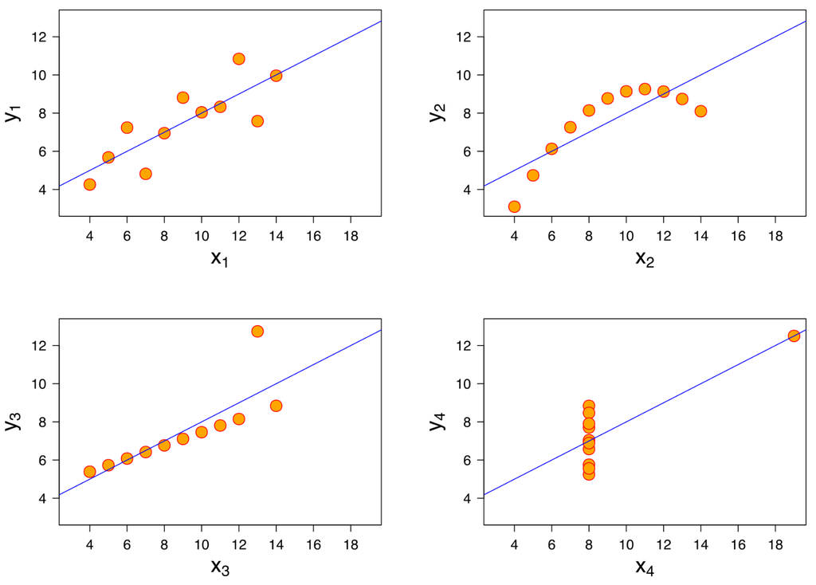

## Visualização é Mapeamento

- **A Gramática dos Gráficos:**
  - Como transformamos dados matemáticos em imagens?
  - Mapeamento em **Atributos Estéticos**: Posição espacial (x, y), Cor, Tamanho, Forma.
- Não se trata de fazer um gráfico bonito, mas sim de fazer o mapeamento mais direto e honesto possível.

## Comunicação Visual: Bons e Maus Exemplos

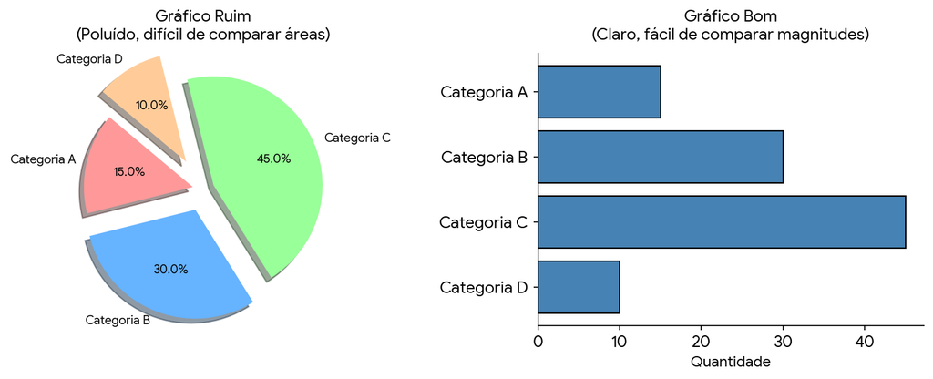

# Linguagem Python

## Linguagem Python - Instalação

- Obtida em https://www.python.org/downloads/
- A forma padrão de instalar pacotes em Python é digitar no terminal:

```bash
pip install <nome do pacote>
```

- Entretanto, a instalação de pacotes (bibliotecas) em Python pode apresentar problemas em algumas situações, especialmente se o pacote possuir funções compiladas em C.

## Linguagem Python - Instalação

- Minha forma preferida de instalar o Python é utilizando o Miniconda:

https://www.anaconda.com/docs/getting-started/miniconda/install/overview

- O Miniconda instala o gerenciador de pacotes conda, que possui algumas vantagens em relação ao pip.
- Após instalar o conda, as diversas bibliotecas utilizadas na disciplina podem ser instaladas. Para as instruções, veja o repositório da disciplina no github

https://github.com/chcomin/curso-processamento-e-visualizacao-de-dados

## Linguagem Python

- Um bom “crash course” contendo diversos comandos Python, Numpy e Matplotlib:
- https://cs231n.github.io/python-numpy-tutorial/